# MATH-256 - Lab #4 - Central Limit Theorem

This lab is aimed at providing practice working with important terms and concepts related to sampling, probability, and Central Limit Theorem. In doing so, it will introduce a useful programming known as a `for` loop, which will facilitate using `R` to conduct simulations.

You should use the same the R Markdown template as you did for Lab #2 - [linked here](https://remiller1450.github.io/m256f20/Lab_2_answer_template.Rmd). Please note that you may need to copy or delete sections to accommodate the different numbers of questions.

Additionally, please upload the “knit” html version of your answers onto Canvas (rather than the .Rmd file in the same location).

## TSA Claims

The Transport Security Administration (TSA) is an agency within the US Department of Homeland Security that has authority of the safety and security of travel in the United States. It was created in response to 9/11, and is most heavily involved in the daily operating procedures of airports.

The TSA screens all persons and personal possessions traveling aboard US airplanes. As a result, thousands of legal claims are filed against the TSA each year regarding stolen or damaged property, improper screening practices, and bodily injury. The code below loads *all claims* made against the TSA in the years 2004 and 2005.

```r
tsa <- read.csv("https://remiller1450.github.io/data/tsa.csv")
```

The variables in this dataset include:

- **Claim_Number**: A unique identifier for the claim
- **Year**: The year in which the event occurred
- **Month**: The month within the specified year
- **Day**: The day within the specified year/month
- **Airport_Code**: An identifier for the airport at which the claim occurred
- **Airline_Name**: The airline that the claimant was traveling on
- **Claim_Type**: The category of the claim
- **Claim_Site**: Where the event occurred
- **Item**: The item being claimed
- **Claim_Amount**: The monetary amount asked for by the claimant
- **Status**: Whether the claim was approved, settled, or denied
- **Close_Amount**: The monetary amount awarded by the TSA to the claimant

**Question #1**: Write `R` code to find the number of cases in this dataset. In the space below your code, make an argument that these data represent a population.

$~$

## Sampling

In Lab #3, we were introduced to the `sample()` function. As its name suggests, the function can be used to draw samples from a population. The code below will draw a sample of size $n = 30$:

```r
sample_IDs <- sample(1:nrow(tsa), size = 30, replace = FALSE)
my_sample <- tsa[sample_IDs, ]
```

Notice how two steps were required. First, we sampled from a list of numbers (1 to the number of cases in the population). Next, we used these 30 identification numbers to select rows from the `tsa` dataset.

### Random Number Seeds

In a purely theoretical sense, it is not feasible for a computer to generate truly random numbers. Instead, programs like `R` use pseudo-random number generators that are based upon inputs which are close to random (for example, the precise system time down to the millisecond).

This means we can actually force `R` to generate the same “random” values consistently if we mandate the same inputs are used. It turns out this is very useful, as it allows us to write reports involving randomness that are replicable (ie: two people each run the code involving random sampling and end up with the same results)

The `set.seed()` function will set a random number generation seed that will cause all subsequent random processes to be replicable. Thus, the following “random” sample will be the same for all of you, no matter how many times you rerun the code:

```r
set.seed(123)
sample_IDs <- sample(1:nrow(tsa), size = 30, replace = FALSE)
my_sample <- tsa[sample_IDs, ]
```

Hopefully its easy to see how setting a seed is might be useful when collaborating on projects involving randomness, or when working on an academic assignment that is to be turned in and evaluated.

### Sampling Variability

Lets look a few different random samples of size $n = 20$, as defined by the seeds 123, 124, 125, 126, and 127.

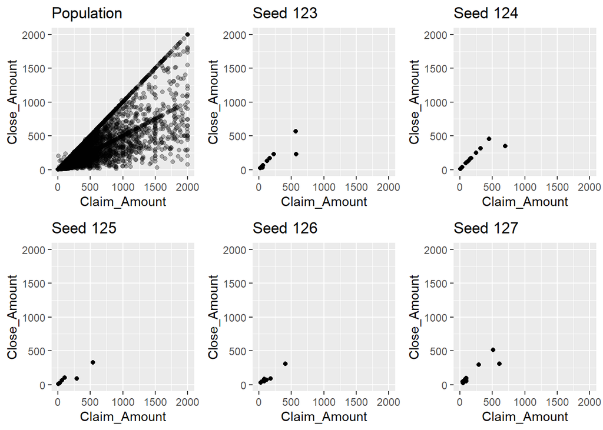

*Note: For visualization purposes, these plots only show claims under $2000, there are numerous outliers in these data that are not displayed.*

The correlation coefficient relating `Claim_Amount` and `Close_Amount` in these five *different random samples* are -0.17, +0.16, -0.17, -0.22, +0.55, respectively. Note that some of these correlations are negative due to the sampling of outliers (not shown) with large claims and close amounts near zero.

**Question #2**: Use the random seed “128” to draw a new random sample (of size $n=20$), then use the `cor` function to find the correlation between `Claim_Amount` and `Close_Amount` in your new sample. Next, find the actual correlation in the *population* and compare it to the six different sample correlations you’ve now seen (seeds 123-127 given above, and seed 128 that you found). Briefly comment on how comfortable you are using the correlation coefficient observed in single random sample to estimate the correlation in the population (recognizing that in any real-world situation you will only see a single sample).

$~$

### Sampling Distributions

It’s a mistake to expect the estimate from any single sample to *exactly* reflect the population parameter because of the variability that is unavoidably introduced by sampling. However, *sampling variability* doesn’t mean that sample estimates are useless (or else statisticians would be unemployed). In fact, statistical methods for quantifying the degree of *sample to sample* variation are some of the most important tools used by statisticians.

#### For Loops

To understand *sampling variability* in greater detail, we’ll first introduce a programming concept known as the `for` loop:

```r
for(i in 1:10){
  print(i)
}
```

```
## [1] 1
## [1] 2
## [1] 3
## [1] 4
## [1] 5
## [1] 6
## [1] 7
## [1] 8
## [1] 9
## [1] 10
```

The code above provides a simple example of a `for` loop. The general idea is to repeat (iterate) a certain block of code, incrementing an index variable (in this case $i$) after each run. Once the index variable has reached the pre-specified maximum the loop repetitions will end. In this example, the code block simply prints the value of $i$ at each of the 10 iterations of the loop.

A more useful `for` loop will store a result from each iteration. The example below stores the correlations of 500 different random samples of size $n = 20$:

```r
## Set a random-number generation seed
set.seed(123)

## Set up an empty vector to store simulation results
cor_results <- rep(NA, 500)

## Use a for loop to generate 500 random samples
for(i in 1:500){
  ## Draw the random sample
  sample_IDs <- sample(1:nrow(tsa), size = 20, replace = FALSE)
  my_sample <- tsa[sample_IDs, ]

  ## Store the correlation
  cor_results[i] <- cor(my_sample$Claim_Amount, my_sample$Close_Amount)
}
```

These simulation results are useful in understanding *sample to sample variation*. The histogram below displays the *sampling variability* in the correlation coefficient relating `Claim_Amount` and `Close_Amount` for random samples of size $n = 20$:

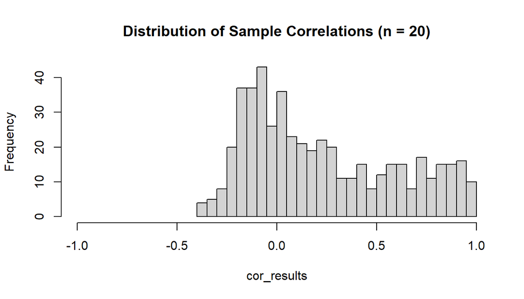

```r
hist(cor_results, breaks = 20, xlim = c(-1,1), main = "Distribution of Sample Correlations (n = 20)")
```

**Question #3**: Describe the shape, center, and spread of the distribution of the sample correlations from our 500 random samples. Use the appropriate function(s) to calculate precise numeric values (for the distribution’s center and spread, you should describe the shape using words). How does the center of this distribution compare to the *actual correlation* between these variables in the population (all TSA claims in 2004 and 2005)?

$~$

## Central Limit Theorem

For *sample averages*, we don’t need to actually draw hundreds of random samples (something that’s impossible in practice) to understand sampling variability. Instead, we can use *Central Limit Theorem* to come up with the distribution of sample estimates.

To illustrate how this works, let’s look at the distribution of sample proportions for “Denied” claims. We’ll consider taking *random samples* of various different sizes and looking at the *sampling distribution* of the proportion of claims that are denied. The code below demonstrates how to do this for a samples of size $n = 10$:

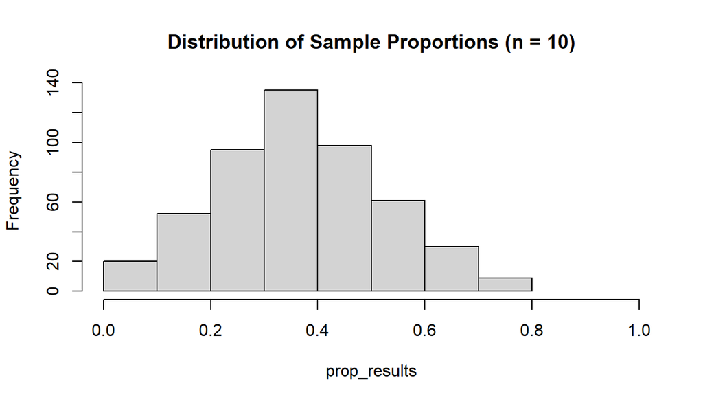

```r
n <- 10

set.seed(123)
prop_results <- rep(NA, 500)
for(i in 1:500){
  ## Draw the random sample
  sample_IDs <- sample(1:nrow(tsa), size = n, replace = FALSE)
  my_sample <- tsa[sample_IDs, ]

  ## Store the proportion
  prop_results[i] <- sum(my_sample$Status == "Denied")/n
}
hist(prop_results, xlim = c(0,1), main = "Distribution of Sample Proportions (n = 10)")
```

**Question #4**: First, modify the code provided above to draw randoms samples of size $n = 30$ and describe any changes you see in the *shape*, *center* and *spread* of the distribution of sample proportions compared to random samples of size $n = 10$. Second, modify the code once more to draw samples of size $n = 100$ and again describe the *shape*, *center* and *spread* of the distribution of sample proportions. What seems to be happening to the *sampling distribution* (distribution of sample proportions) as the size of our samples increases?

$~$

Recall that Central Limit Theorem states that if $X_1, X_2, \ldots, X_n$ are independent random variables with expected value $E(X) = \mu$ and variance $Var(X) = \sigma^2$, and $\bar{X}$ is the sample average, then $\bar{X} \sim N(\mu, \sigma/\sqrt{n})$.

The beauty of CLT is that it allows us to anticipate what the histograms of sample averages will look like *without actually needing to repeatedly take random samples*. This has incredible real-world utility, since it’s impractical to sample a population hundreds of times.

**Question #5**: Using the entire dataset (the population), `tsa`, find the true proportion of “Denied” claims, $p$. Then use central limit theorem to find a normal approximation of the distribution of sample proportions, $\hat{p}$. Store $p$ as an `R` object `p`, and save the standard deviation of your normal curve as an `R` object `se`.

$~$

**Question #6**: Copy the `for` loop you used to generate random samples of size $n = 100$, then add the three lines of code shown below to draw a histogram with the CLT normal approximation overlaid. It should produce a graph that matches the one shown below (assuming you used `set.seed(123)`).

$~$

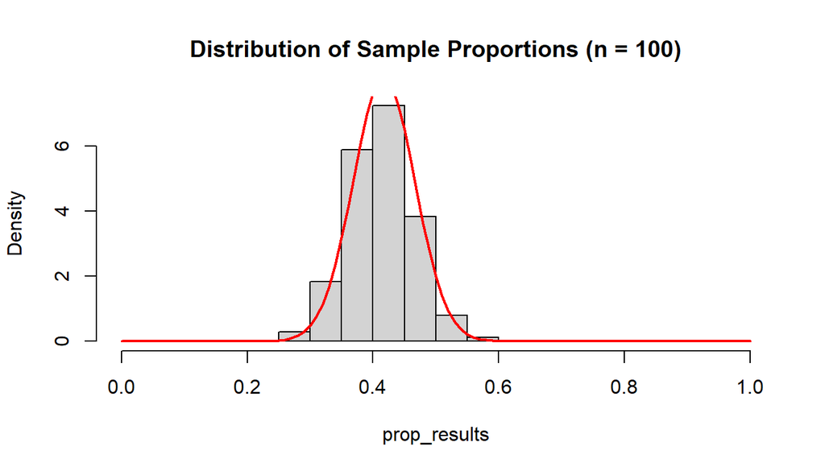

```r
hist(prop_results, xlim = c(0,1), main = "Distribution of Sample Proportions (n = 100)", probability = TRUE)
xx <- seq(0,1, by = .01)
lines(xx, dnorm(xx, p, se), col = "red", lwd = 2)
```

**Question 7**: Using your CLT normal approximation of the distribution of sample proportions. Find the interval containing the middle 95% of possible sample proportions you’d expect to see in a sample of size $n = 100$. How far *above* and *below* the true population proportion might you expect to see (in 95% of random samples)?

$~$

### Next Steps

By studying the variability in sample estimates prepare ourselves to take on the two primary goals of *statistical inference*:

1. **Estimation** - Using sample data to infer something about a broader population. For example, we might use a sample of claims against the TSA to predict the likelihood that a future claim is denied (ie: using the sample proportion, $\hat{p}$, to estimate the population proportion, $p$)
2. **Hypothesis Testing** - Using sample data to reach a conclusion about a particular null model. For example, we might use a sample of 16 infants toy choices to determine whether the null model that each choice was a coin flip is plausible.

Central Limit Theorem provides us a way of knowing the variability of sample averages, which will be the basis for calculating *interval estimates* and *$p$-values* without requiring a large number of samples or repetitions of a study.